# CP03 PISA

Carlos Serrano Valera

05/11/2020

```r
library(here) # Agilidad en la carga de datos
library(tidyverse)
library(janitor) # Limpiar nombres de variables
library(skimr) # Un summary mas comleto
library(magrittr) # Operadores pipe
library(corrplot) # Correlaciones
library(ggcorrplot)  # Correlaciones
library(splines)  # Para los modelos de splines
library(gam)   # Modelo GAM
```

# Datos

```r
raw_data <-  read.csv("pisasci2006.csv")
colnames(raw_data)
```

```
##  [1] "Country"  "Overall"  "Issues"   "Explain"  "Evidence" "Interest"
##  [7] "Support"  "Income"   "Health"   "Edu"      "HDI"
```

# Nombres de las variables

Limpiamos con clean_names() para hacer más manejables los nombres de las variables

```r
raw_data %<>% clean_names()
colnames(raw_data)
```

```
##  [1] "country"  "overall"  "issues"   "explain"  "evidence" "interest"
##  [7] "support"  "income"   "health"   "edu"      "hdi"
```

# Summary

Data summary

| Name | raw_data |
| --- | --- |
| Number of rows | 65 |
| Number of columns | 11 |
| _______________________ |  |
| Column type frequency: |  |
| character | 1 |
| numeric | 10 |
| ________________________ |  |
| Group variables | None |

**Variable type: character**

| skim_variable | n_missing | complete_rate | min | max | empty | n_unique | whitespace |
| --- | --- | --- | --- | --- | --- | --- | --- |
| country | 0 | 1 | 4 | 24 | 0 | 65 | 0 |

**Variable type: numeric**

| skim_variable | n_missing | complete_rate | mean | sd | p0 | p25 | p50 | p75 | p100 | hist |
| --- | --- | --- | --- | --- | --- | --- | --- | --- | --- | --- |
| overall | 8 | 0.88 | 473.14 | 54.58 | 322.00 | 428.00 | 489.00 | 513.00 | 563.00 | ▁▃▂▇▅ |
| issues | 8 | 0.88 | 469.91 | 53.93 | 321.00 | 427.00 | 489.00 | 514.00 | 555.00 | ▁▃▂▇▆ |
| explain | 8 | 0.88 | 475.02 | 54.02 | 334.00 | 432.00 | 490.00 | 517.00 | 566.00 | ▁▃▂▇▃ |
| evidence | 8 | 0.88 | 469.81 | 61.74 | 288.00 | 423.00 | 489.00 | 515.00 | 567.00 | ▁▂▃▇▆ |
| interest | 8 | 0.88 | 528.16 | 49.84 | 448.00 | 501.00 | 522.00 | 565.00 | 644.00 | ▆▇▅▃▂ |
| support | 8 | 0.88 | 512.18 | 26.08 | 447.00 | 494.00 | 512.00 | 529.00 | 569.00 | ▂▅▇▆▂ |
| income | 4 | 0.94 | 0.74 | 0.11 | 0.41 | 0.66 | 0.76 | 0.83 | 0.94 | ▁▃▇▇▆ |
| health | 4 | 0.94 | 0.89 | 0.07 | 0.72 | 0.84 | 0.89 | 0.94 | 0.99 | ▂▂▇▆▇ |
| edu | 6 | 0.91 | 0.80 | 0.11 | 0.54 | 0.72 | 0.81 | 0.88 | 0.99 | ▂▅▆▇▅ |
| hdi | 6 | 0.91 | 0.81 | 0.09 | 0.58 | 0.75 | 0.82 | 0.88 | 0.94 | ▁▃▇▇▇ |

Hay algunos NAs, que voy a eliminar

Data summary

| Name | raw_data |
| --- | --- |
| Number of rows | 52 |
| Number of columns | 11 |
| _______________________ |  |
| Column type frequency: |  |
| character | 1 |
| numeric | 10 |
| ________________________ |  |
| Group variables | None |

**Variable type: character**

| skim_variable | n_missing | complete_rate | min | max | empty | n_unique | whitespace |
| --- | --- | --- | --- | --- | --- | --- | --- |
| country | 0 | 1 | 5 | 18 | 0 | 52 | 0 |

**Variable type: numeric**

| skim_variable | n_missing | complete_rate | mean | sd | p0 | p25 | p50 | p75 | p100 | hist |
| --- | --- | --- | --- | --- | --- | --- | --- | --- | --- | --- |
| overall | 0 | 1 | 471.15 | 53.99 | 322.00 | 427.00 | 488.00 | 511.25 | 563.00 | ▁▃▃▇▃ |
| issues | 0 | 1 | 469.08 | 52.78 | 321.00 | 427.00 | 484.50 | 511.00 | 555.00 | ▁▃▃▇▆ |
| explain | 0 | 1 | 472.52 | 54.07 | 334.00 | 430.50 | 487.00 | 516.25 | 566.00 | ▁▃▂▇▃ |
| evidence | 0 | 1 | 467.65 | 59.87 | 288.00 | 421.50 | 488.00 | 511.75 | 567.00 | ▁▂▃▇▅ |
| interest | 0 | 1 | 527.81 | 50.42 | 448.00 | 498.00 | 522.00 | 565.50 | 644.00 | ▆▇▅▃▂ |
| support | 0 | 1 | 510.88 | 26.37 | 447.00 | 491.75 | 511.50 | 529.00 | 569.00 | ▂▃▇▅▂ |
| income | 0 | 1 | 0.75 | 0.11 | 0.41 | 0.68 | 0.77 | 0.83 | 0.91 | ▁▁▆▅▇ |
| health | 0 | 1 | 0.89 | 0.06 | 0.74 | 0.84 | 0.91 | 0.94 | 0.99 | ▂▃▆▆▇ |
| edu | 0 | 1 | 0.81 | 0.11 | 0.54 | 0.76 | 0.83 | 0.90 | 0.99 | ▂▃▆▇▆ |
| hdi | 0 | 1 | 0.81 | 0.09 | 0.58 | 0.76 | 0.84 | 0.88 | 0.94 | ▁▃▆▆▇ |

Las variables overall, issues, explain y evidence parecen tener una distribución muy similar.

También parece haber una similitud entre income, health, edu y hdi. Esto tiene sentido ya la última contiene a las tres primeras.

Para observar la relación entre la puntuación media (overall) y el resto de variables, dibujo gráficos de dispersión, que incluye un ajuste lineal entre las variables.

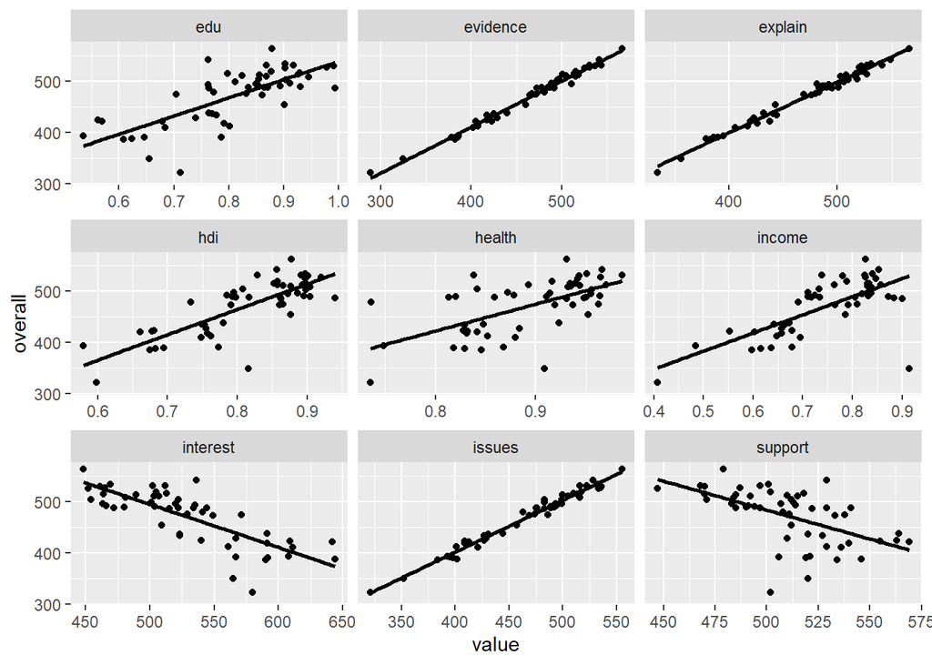

Las variables issues, evidence y explain tiene una relación lineal con la variable de interés “overall”. La relación de esta con las demás variables no es tan evidente pero sí se puede decir que tiende igualmente hacia una relación lineal.

# EDA

## Correlaciones

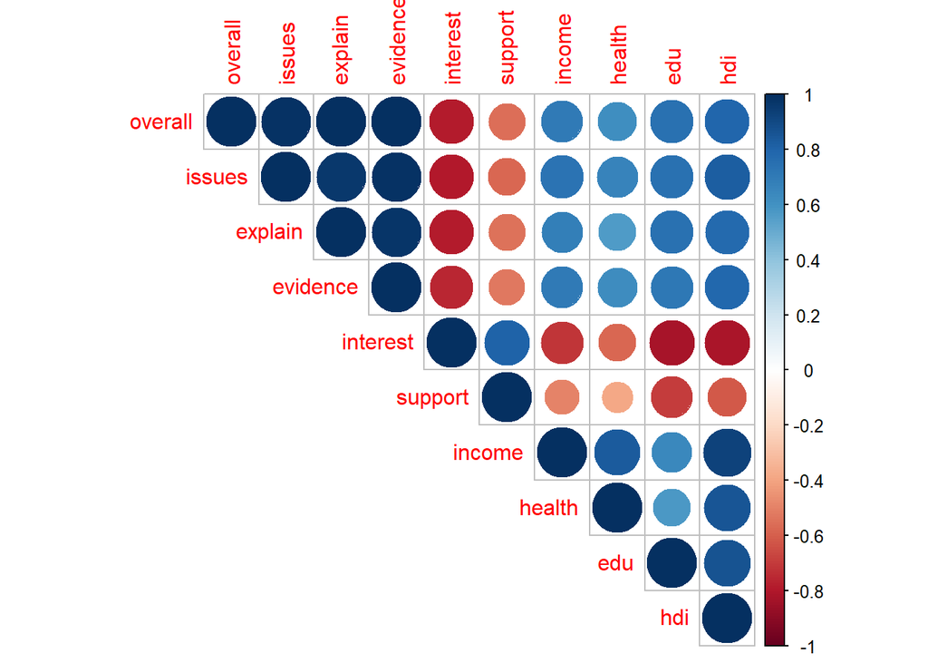

```r
pisa <- raw_data

# Correlaciones
corrplot(cor(pisa %>%
               select_at(vars(-country)),
             use = "complete.obs"),
         method = "circle",type = "upper")
```

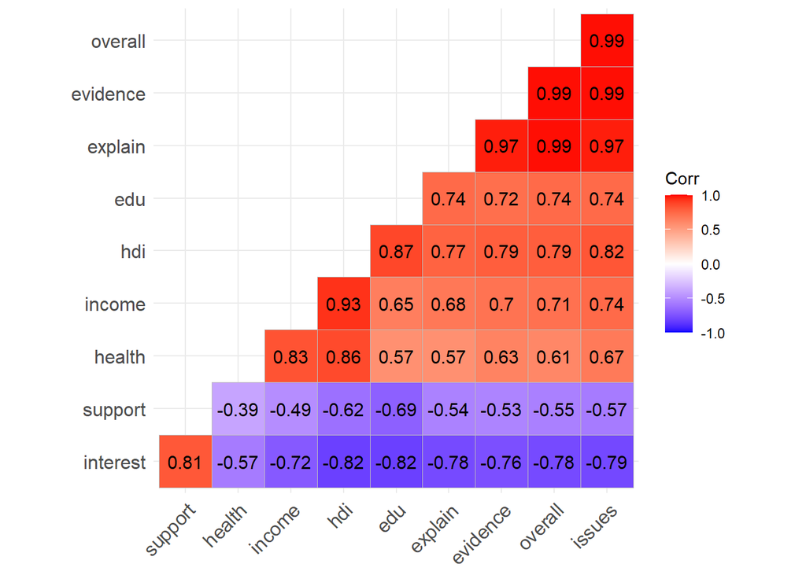

```r
# Otra manera


ggcorrplot(cor(pisa %>%
               select_at(vars(-country)),
            use = "complete.obs"),
            hc.order = TRUE,
            type = "lower",  lab = TRUE)
```

Hay una fuerte correlación positiva entre overall, issues, evidence y explain. Esta información y la extraída anteriormente conduce a pensar que las tres últimas variables, aporten poco en la predicción de la primera. Por ello, las voy a omitir para el resto del análisis.

# Splines

Vamos a ajustar un modelo que explique la relación de overall con las demás variables relevantes. Para ello, ajustamos splines suavizados para cada una de ellas. Con esto obtendremos, mediante cross validation, los grados de libertad deseados para cada variable a la hora de construir el modelo GAM.

```r
# La funcion smooth.spline utiliza cv para obtener los grados de libertad optimos

fitEdu <- smooth.spline(pisa$edu, pisa$overall)

fitHdi <- smooth.spline(pisa$hdi, pisa$overall)

fitIncome <- smooth.spline(pisa$income, pisa$overall)

fitHealth <- smooth.spline(pisa$health, pisa$overall)

fitSupport <- smooth.spline(pisa$support, pisa$overall)

fitInterest <- smooth.spline(pisa$interest, pisa$overall)
```

# Modelo GAM

Tras el CV, obtenemos los nudos (k) con los que va a ser ajustada cada variable en el modelo.

He omitido en el modelo la variable Income ya que había riesgo de sobreajuste, porque los grados de libertad obtenidos eran 48.8

```r
fitIncome$df
```

```
## [1] 48.81809
```

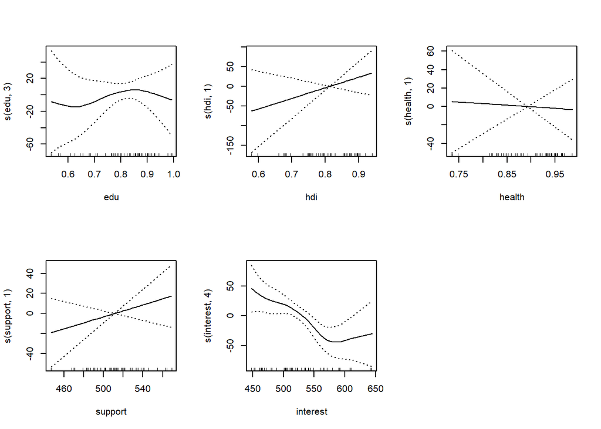

```r
gamPisa <- gam(overall ~ s(edu, 3) + s(hdi, 1) + s(health, 1) + s(support, 1) +
             s(interest, 4), data = pisa)

par(mfrow=c(2, 3))
plot(gamPisa, se = TRUE)
```